# Common Fate Model

```r
library(interdep)
library(lavaan)
```

> This vignette is a draft and is under construction.

The Common Fate Model (CFM) represents the two members’ reports as indicators of a shared latent dyad-level construct (Ledermann and Kenny 2017; Iida, Seidman, and Shrout 2018). In the predictor-to-outcome CFM below, the shared predictor level predicts the shared outcome level. The unit-loading paths define each latent variable from the two member reports.

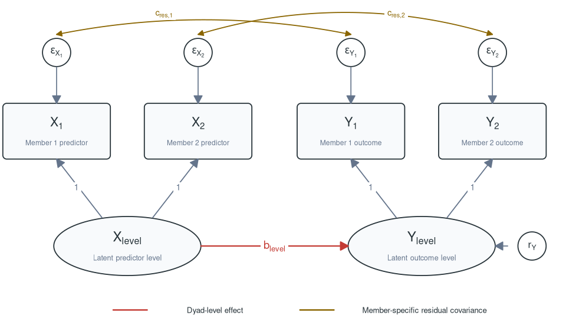

SEM representation of a predictor-to-outcome Common Fate Model. Each pair of member reports loads with a fixed unit loading on a shared latent dyad-level construct. The latent predictor level predicts the latent outcome level. Same-member predictor and outcome residuals may covary, and the latent outcome level has a residual disturbance.

The curved paths, labelled $c_{\mathrm{res},1}$ and $c_{\mathrm{res},2}$, retain the predictor–outcome association specific to each member rather than assigning it to the shared dyad-level effect. To match the DIM and DSM diagrams, the shared-level path uses the predictor-mean/between- dyad field color, whereas the member-specific residual paths use the within-dyad field color. These colors describe fields of variation, not actor and partner effects. Only the SEM representation is shown here; there is no individual-level multilevel-model diagram for this CFM.

## Model specification

Each shared level is represented by a two-indicator confirmatory factor model. The regression between those two latent levels makes the complete CFM a structural equation model.

For dyad $j$ and member $i \in \{1, 2\}$, the standard CFM can be written as

$$X_{ij} = X_{\mathrm{level},j} + \varepsilon_{Xij}, \qquad
Y_{ij} = Y_{\mathrm{level},j} + \varepsilon_{Yij},$$

with the dyad-level regression

$$Y_{\mathrm{level},j}
= b_{\mathrm{level}}X_{\mathrm{level},j} + r_{Yj}.$$

Following Model 4 of Iida et al. (2018), **both** loadings for each latent variable are fixed to 1. This differs from `lavaan`’s usual marker-variable default, which fixes only one loading. The unit loadings treat the two reports symmetrically and keep the latent variables on the original measurement scales; they do not define the latent scores as literal arithmetic averages.

The model freely estimates:

- the variance of the latent predictor level and the residual variance of the latent outcome level;
- all four indicator residual variances;
- the dyad-level regression $b_{\mathrm{level}}$; and
- the two same-member predictor–outcome residual covariances.

All other indicator residual covariances are fixed to zero by omission. Iida et al.’s standard CFM does not constrain the two members’ intercepts, residual variances, or same-member residual covariances to be equal. With a mean structure, the four observed intercepts are free and the two latent means are fixed to zero. The mean structure is therefore saturated and does not change the model’s one degree of freedom. At the covariance level, the model estimates nine parameters from the ten unique observed covariance elements, leaving one degree of freedom.

## Data

To compare the CFM directly with the other vignettes, we use the same `example_dyadic_crosssectional` data, with `communication` as the predictor and `satisfaction` as the outcome. `lavaan` represents the two members as separate observed variables, so the long-format data first need one row per dyad.

```r
cfm_data <- reshape(
  example_dyadic_crosssectional[
    c("coupleID", "gender", "communication", "satisfaction")
  ],
  idvar = "coupleID",
  timevar = "gender",
  direction = "wide"
)

names(cfm_data) <- gsub(".", "_", names(cfm_data), fixed = TRUE)
cfm_data <- cfm_data[
  c(
    "coupleID",
    "communication_female", "communication_male",
    "satisfaction_female", "satisfaction_male"
  )
]
row.names(cfm_data) <- NULL

head(cfm_data)
```

```
#>   coupleID communication_female communication_male satisfaction_female
#> 1        1             4.789772           3.803445            4.367824
#> 2        2             2.914052           6.508207            2.442250
#> 3        3             5.696995           8.215332            5.865494
#> 4        4             5.282135           4.894840            6.504796
#> 5        5             6.005546           4.318964            7.405502
#> 6        6             7.736048           6.568731            7.850462
#>   satisfaction_male
#> 1          2.342890
#> 2          6.080428
#> 3          9.661295
#> 4          3.077529
#> 5          1.466225
#> 6          9.843615
```

The `lavaan` syntax directly follows Iida et al.’s Mplus specification, now using the variables from the package example:

```r
cfm_model <- '
  # Shared dyad levels: fix all four loadings to 1
  communication_level =~
    1 * communication_female + 1 * communication_male
  satisfaction_level =~
    1 * satisfaction_female + 1 * satisfaction_male

  # Dyad-level association
  satisfaction_level ~ b_level * communication_level

  # Same-member residual covariances
  communication_female ~~ c_female * satisfaction_female
  communication_male ~~ c_male * satisfaction_male
'
```

Observed residual variances, the latent communication variance, and the latent satisfaction disturbance variance are free by default. The four observed intercepts are also freely estimated. Full-information maximum likelihood uses all dyads, including those with a partially missing member report.

```r
cfm_fit <- suppressWarnings(
  sem(
    cfm_model,
    data = cfm_data,
    estimator = "ML",
    missing = "fiml",
    meanstructure = TRUE
  )
)

loading_constraints <- parameterTable(cfm_fit)
loading_constraints <- loading_constraints[
  loading_constraints$op == "=~",
]

cfm_admissible <- suppressWarnings(lavInspect(cfm_fit, "post.check"))

stopifnot(
  lavInspect(cfm_fit, "converged"),
  fitMeasures(cfm_fit, "df") == 1,
  nrow(loading_constraints) == 4,
  all(loading_constraints$free == 0),
  all(loading_constraints$ustart == 1),
  all(loading_constraints$est == 1)
)
```

The checks above verify convergence, the expected one degree of freedom, and that all four unstandardized loadings remain fixed at exactly 1. Admissibility is checked separately because convergence alone does not rule out impossible variance estimates.

> **Model diagnostic:** The model converged, but the latent satisfaction disturbance variance is -0.60. This negative variance makes the solution inadmissible, so its paths and fit indices should not be interpreted substantively.

### Fitted model

The fitted diagram is generated from `cfm_fit`: none of its displayed numbers are typed into the figure. For an admissible solution, the shared-level path shows both the unstandardized effect and standardized $\beta$, and the latent outcome shows $R^2$. For an inadmissible solution, the diagram instead displays the offending variance. The curved-path labels are residual **correlations**, which are easier to compare than scale-dependent covariances.

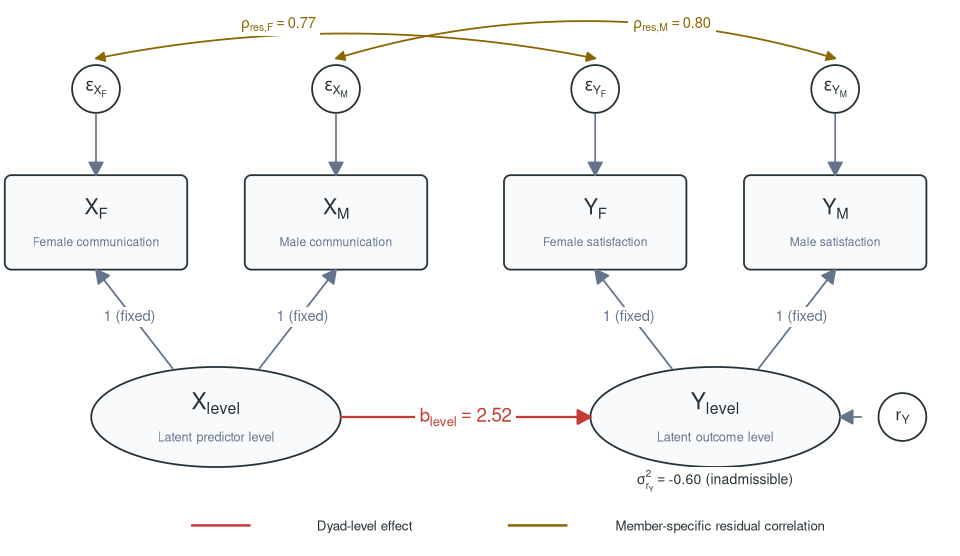

Fitted standard CFM for the package’s cross-sectional example. All four unstandardized loadings are fixed at 1. The shared-level path and same-member residual correlations are read directly from the fitted model. The label below the latent outcome reports R-squared for an admissible solution or flags an inadmissible variance.

The model estimates a shared dyad-level coefficient of $b_{\mathrm{level}} = 2.52$. If the CFM solution were admissible, this would mean that a one-unit higher latent shared communication level is associated with a 2.52-unit higher latent shared satisfaction level. However, the model estimates a negative latent satisfaction disturbance variance. The solution is therefore inadmissible, and this coefficient should not be interpreted as a reliable substantive estimate.

The indicator residual variances and latent outcome disturbance variance are reported separately below. The freely estimated observed intercepts reproduce the four member-specific means and are omitted from the diagram.

Model fit for the package’s cross-sectional example.

| Measure | Estimate |
| --- | --- |
| Chi-square | 0.037 |
| df | 1.000 |
| p | 0.848 |
| CFI | 1.000 |
| TLI | 1.019 |
| RMSEA | 0.000 |
| SRMR | 0.004 |

Key estimates from the standard CFM.

| Parameter | Estimate | SE | p | Standardized estimate |
| --- | --- | --- | --- | --- |
| Dyad-level effect | 2.520 | 0.339 | 0 | 1.099 |
| Female residual covariance | 1.584 | 0.444 | 0 | 0.773 |
| Male residual covariance | 2.389 | 0.525 | 0 | 0.798 |

Residual variance estimates. A negative value identifies an inadmissible solution.

| Parameter | Unstandardized variance | Standardized residual variance |
| --- | --- | --- |
| Female communication residual | 1.138 | 0.673 |
| Male communication residual | 1.472 | 0.727 |
| Female satisfaction residual | 3.694 | 0.559 |
| Male satisfaction residual | 6.088 | 0.676 |
| Latent satisfaction disturbance | -0.604 | -0.207 |

We do not force the negative variance to zero. Such a bound would change the estimation problem, place the estimate on the boundary, and require additional care for uncertainty and model-fit tests. If the example data are changed later, the diagnostic text and fitted diagram will update from the new model fit.

Iida, Masumi, Gwendolyn Seidman, and Patrick E. Shrout. 2018. “Models of Interdependent Individuals Versus Dyadic Processes in Relationship Research.” *Journal of Social and Personal Relationships* 35 (1): 59–88. https://doi.org/10.1177/0265407517725407.

Ledermann, Thomas, and David A. Kenny. 2017. “Analyzing Dyadic Data with Multilevel Modeling Versus Structural Equation Modeling: A Tale of Two Methods.” *Journal of Family Psychology* 31 (4): 442–52. https://doi.org/10.1037/fam0000290.